# 基于机器学习与深度学习的乳腺癌良恶性分类研究

## 一、实验背景

乳腺癌（Breast Cancer）是全球女性群体中最常见的恶性肿瘤之一，也是导致女性癌症死亡的重要原因。根据世界卫生组织（WHO）的统计数据，乳腺癌已成为全球发病率最高的癌症之一。早期发现和准确诊断对于提高患者生存率具有重要意义。 传统的乳腺癌诊断主要依赖医生根据病理学检查结果进行判断。然而随着医学数据积累和人工智能技术的发展，利用机器学习与深度学习模型辅助诊断逐渐成为研究热点。通过对细胞形态学特征进行分析，分类模型能够自动判断肿瘤属于良性（Benign）还是恶性（Malignant），从而为临床诊断提供辅助决策支持。 本实验基于Kaggle平台公开发布的 Breast Cancer Wisconsin 数据集，利用机器学习和深度学习方法构建乳腺癌分类模型。实验不仅关注模型最终分类性能，同时还将深入分析数据特征分布、变量相关性、降维结构、训练过程以及模型可解释性，从多个角度探讨不同算法在医学诊断场景下的适用性与局限性。 与传统实验仅采用单一模型不同，本实验设计了六种具有代表性的分类方法，包括多层感知机、径向基神经网络、遗传算法优化MLP、残差神经网络、Transformer编码器以及自编码器特征学习模型，并通过Accuracy、Precision、Recall、F1-score、ROC-AUC以及训练时间等多个指标进行综合评价。

## 实验目标

本实验主要完成以下目标： 1. 下载并构建Breast Cancer Wisconsin数据集； 2. 对数据进行探索性分析（EDA），研究各特征分布规律； 3. 利用相关性分析发现重要医学指标； 4. 使用PCA和t-SNE可视化高维数据结构； 5. 构建六种不同分类模型完成良恶性肿瘤分类； 6. 对模型性能进行系统比较； 7. 结合可解释性分析研究模型决策依据； 8. 总结机器学习与深度学习在医学诊断中的优势与不足。

```python
import kagglehub

path = kagglehub.dataset_download(
    "priyanka841/breast-cancer-wisconsin",
    output_dir="./data"
)

print(path)
```

```
./data
```

## 二、数据获取与预处理

本实验使用Kaggle平台公开发布的 Breast Cancer Wisconsin 数据集。 该数据集来源于美国威斯康星大学医学中心乳腺癌细胞病理检测结果，通过细针穿刺（Fine Needle Aspiration，FNA）获得细胞图像后提取多个形态学特征。 数据集中每个样本对应一名患者，每个特征描述细胞核的几何性质，例如：

- 半径（Radius）
- 纹理（Texture）
- 周长（Perimeter）
- 面积（Area）
- 光滑度（Smoothness）
- 紧凑度（Compactness）
- 对称性（Symmetry）

目标变量：

- M：Malignant（恶性）
- B：Benign（良性）

属于典型二分类问题。

```python
import numpy as np
import pandas as pd
import os
import time

import matplotlib.pyplot as plt
import seaborn as sns

from sklearn.model_selection import train_test_split
from sklearn.preprocessing import StandardScaler

plt.rcParams['figure.figsize'] = (8,6)
plt.rcParams['font.sans-serif'] = ['SimHei']
plt.rcParams['axes.unicode_minus'] = False

print("[OK] 所有库导入成功")
```

```
[OK] 所有库导入成功
```

```python
import os
os.listdir("./data")
```

```
['.complete', 'Breast Cancer Dignostics.ipynb', 'breast cancer.csv']
```

```python
df = pd.read_csv("./data/breast cancer.csv")
df.head()
```

|  | id | diagnosis | radius_mean | texture_mean | perimeter_mean | area_mean | smoothness_mean | compactness_mean | concavity_mean | concave points_mean | ... | texture_worst | perimeter_worst | area_worst | smoothness_worst | compactness_worst | concavity_worst | concave points_worst | symmetry_worst | fractal_dimension_worst | Unnamed: 32 |
| --- | --- | --- | --- | --- | --- | --- | --- | --- | --- | --- | --- | --- | --- | --- | --- | --- | --- | --- | --- | --- | --- |
| 0 | 842302 | M | 17.99 | 10.38 | 122.80 | 1001.0 | 0.11840 | 0.27760 | 0.3001 | 0.14710 | ... | 17.33 | 184.60 | 2019.0 | 0.1622 | 0.6656 | 0.7119 | 0.2654 | 0.4601 | 0.11890 | NaN |
| 1 | 842517 | M | 20.57 | 17.77 | 132.90 | 1326.0 | 0.08474 | 0.07864 | 0.0869 | 0.07017 | ... | 23.41 | 158.80 | 1956.0 | 0.1238 | 0.1866 | 0.2416 | 0.1860 | 0.2750 | 0.08902 | NaN |
| 2 | 84300903 | M | 19.69 | 21.25 | 130.00 | 1203.0 | 0.10960 | 0.15990 | 0.1974 | 0.12790 | ... | 25.53 | 152.50 | 1709.0 | 0.1444 | 0.4245 | 0.4504 | 0.2430 | 0.3613 | 0.08758 | NaN |
| 3 | 84348301 | M | 11.42 | 20.38 | 77.58 | 386.1 | 0.14250 | 0.28390 | 0.2414 | 0.10520 | ... | 26.50 | 98.87 | 567.7 | 0.2098 | 0.8663 | 0.6869 | 0.2575 | 0.6638 | 0.17300 | NaN |
| 4 | 84358402 | M | 20.29 | 14.34 | 135.10 | 1297.0 | 0.10030 | 0.13280 | 0.1980 | 0.10430 | ... | 16.67 | 152.20 | 1575.0 | 0.1374 | 0.2050 | 0.4000 | 0.1625 | 0.2364 | 0.07678 | NaN |

5 rows × 33 columns

## 数据集初步观察

首先查看数据集基本结构。 通过观察前几行数据可以发现：

- 每一行对应一位患者；
- diagnosis 为分类标签；
- M表示恶性肿瘤；
- B表示良性肿瘤；
- 其余字段为细胞核形态学特征。

这些特征均来源于病理图像分析结果，是后续分类的重要依据。

```python
df.shape
```

```
(569, 33)
```

```python
df.info()
```

```
<class 'pandas.DataFrame'>
RangeIndex: 569 entries, 0 to 568
Data columns (total 33 columns):
 #   Column                   Non-Null Count  Dtype
---  ------                   --------------  -----
 0   id                       569 non-null    int64
 1   diagnosis                569 non-null    str
 2   radius_mean              569 non-null    float64
 3   texture_mean             569 non-null    float64
 4   perimeter_mean           569 non-null    float64
 5   area_mean                569 non-null    float64
 6   smoothness_mean          569 non-null    float64
 7   compactness_mean         569 non-null    float64
 8   concavity_mean           569 non-null    float64
 9   concave points_mean      569 non-null    float64
```

[output cut: 25 more lines]

```python
df.describe().T
```

|  | count | mean | std | min | 25% | 50% | 75% | max |
| --- | --- | --- | --- | --- | --- | --- | --- | --- |
| id | 569.0 | 3.037183e+07 | 1.250206e+08 | 8670.000000 | 869218.000000 | 906024.000000 | 8.813129e+06 | 9.113205e+08 |
| radius_mean | 569.0 | 1.412729e+01 | 3.524049e+00 | 6.981000 | 11.700000 | 13.370000 | 1.578000e+01 | 2.811000e+01 |
| texture_mean | 569.0 | 1.928965e+01 | 4.301036e+00 | 9.710000 | 16.170000 | 18.840000 | 2.180000e+01 | 3.928000e+01 |
| perimeter_mean | 569.0 | 9.196903e+01 | 2.429898e+01 | 43.790000 | 75.170000 | 86.240000 | 1.041000e+02 | 1.885000e+02 |
| area_mean | 569.0 | 6.548891e+02 | 3.519141e+02 | 143.500000 | 420.300000 | 551.100000 | 7.827000e+02 | 2.501000e+03 |
| smoothness_mean | 569.0 | 9.636028e-02 | 1.406413e-02 | 0.052630 | 0.086370 | 0.095870 | 1.053000e-01 | 1.634000e-01 |
| compactness_mean | 569.0 | 1.043410e-01 | 5.281276e-02 | 0.019380 | 0.064920 | 0.092630 | 1.304000e-01 | 3.454000e-01 |
| concavity_mean | 569.0 | 8.879932e-02 | 7.971981e-02 | 0.000000 | 0.029560 | 0.061540 | 1.307000e-01 | 4.268000e-01 |
| concave points_mean | 569.0 | 4.891915e-02 | 3.880284e-02 | 0.000000 | 0.020310 | 0.033500 | 7.400000e-02 | 2.012000e-01 |
| symmetry_mean | 569.0 | 1.811619e-01 | 2.741428e-02 | 0.106000 | 0.161900 | 0.179200 | 1.957000e-01 | 3.040000e-01 |
| fractal_dimension_mean | 569.0 | 6.279761e-02 | 7.060363e-03 | 0.049960 | 0.057700 | 0.061540 | 6.612000e-02 | 9.744000e-02 |
| radius_se | 569.0 | 4.051721e-01 | 2.773127e-01 | 0.111500 | 0.232400 | 0.324200 | 4.789000e-01 | 2.873000e+00 |
| texture_se | 569.0 | 1.216853e+00 | 5.516484e-01 | 0.360200 | 0.833900 | 1.108000 | 1.474000e+00 | 4.885000e+00 |
| perimeter_se | 569.0 | 2.866059e+00 | 2.021855e+00 | 0.757000 | 1.606000 | 2.287000 | 3.357000e+00 | 2.198000e+01 |
| area_se | 569.0 | 4.033708e+01 | 4.549101e+01 | 6.802000 | 17.850000 | 24.530000 | 4.519000e+01 | 5.422000e+02 |
| smoothness_se | 569.0 | 7.040979e-03 | 3.002518e-03 | 0.001713 | 0.005169 | 0.006380 | 8.146000e-03 | 3.113000e-02 |
| compactness_se | 569.0 | 2.547814e-02 | 1.790818e-02 | 0.002252 | 0.013080 | 0.020450 | 3.245000e-02 | 1.354000e-01 |
| concavity_se | 569.0 | 3.189372e-02 | 3.018606e-02 | 0.000000 | 0.015090 | 0.025890 | 4.205000e-02 | 3.960000e-01 |
| concave points_se | 569.0 | 1.179614e-02 | 6.170285e-03 | 0.000000 | 0.007638 | 0.010930 | 1.471000e-02 | 5.279000e-02 |
| symmetry_se | 569.0 | 2.054230e-02 | 8.266372e-03 | 0.007882 | 0.015160 | 0.018730 | 2.348000e-02 | 7.895000e-02 |
| fractal_dimension_se | 569.0 | 3.794904e-03 | 2.646071e-03 | 0.000895 | 0.002248 | 0.003187 | 4.558000e-03 | 2.984000e-02 |
| radius_worst | 569.0 | 1.626919e+01 | 4.833242e+00 | 7.930000 | 13.010000 | 14.970000 | 1.879000e+01 | 3.604000e+01 |
| texture_worst | 569.0 | 2.567722e+01 | 6.146258e+00 | 12.020000 | 21.080000 | 25.410000 | 2.972000e+01 | 4.954000e+01 |
| perimeter_worst | 569.0 | 1.072612e+02 | 3.360254e+01 | 50.410000 | 84.110000 | 97.660000 | 1.254000e+02 | 2.512000e+02 |
| area_worst | 569.0 | 8.805831e+02 | 5.693570e+02 | 185.200000 | 515.300000 | 686.500000 | 1.084000e+03 | 4.254000e+03 |
| smoothness_worst | 569.0 | 1.323686e-01 | 2.283243e-02 | 0.071170 | 0.116600 | 0.131300 | 1.460000e-01 | 2.226000e-01 |
| compactness_worst | 569.0 | 2.542650e-01 | 1.573365e-01 | 0.027290 | 0.147200 | 0.211900 | 3.391000e-01 | 1.058000e+00 |
| concavity_worst | 569.0 | 2.721885e-01 | 2.086243e-01 | 0.000000 | 0.114500 | 0.226700 | 3.829000e-01 | 1.252000e+00 |
| concave points_worst | 569.0 | 1.146062e-01 | 6.573234e-02 | 0.000000 | 0.064930 | 0.099930 | 1.614000e-01 | 2.910000e-01 |
| symmetry_worst | 569.0 | 2.900756e-01 | 6.186747e-02 | 0.156500 | 0.250400 | 0.282200 | 3.179000e-01 | 6.638000e-01 |
| fractal_dimension_worst | 569.0 | 8.394582e-02 | 1.806127e-02 | 0.055040 | 0.071460 | 0.080040 | 9.208000e-02 | 2.075000e-01 |
| Unnamed: 32 | 0.0 | NaN | NaN | NaN | NaN | NaN | NaN | NaN |

## 数据规模分析

从数据集信息可以发现： 本数据集共包含569个样本以及30个主要特征。 相比于图像数据集，本数据集属于典型的小样本医学数据集。 因此模型在训练过程中容易出现过拟合问题。 后续实验将特别关注模型泛化能力。

```python
df.isnull().sum()
```

```
id                           0
diagnosis                    0
radius_mean                  0
texture_mean                 0
perimeter_mean               0
area_mean                    0
smoothness_mean              0
compactness_mean             0
concavity_mean               0
concave points_mean          0
symmetry_mean                0
fractal_dimension_mean       0
radius_se                    0
texture_se                   0
perimeter_se                 0
area_se                      0
smoothness_se                0
compactness_se               0
concavity_se                 0
concave points_se            0
symmetry_se                  0
fractal_dimension_se         0
radius_worst                 0
texture_worst                0
perimeter_worst              0
area_worst                   0
smoothness_worst             0
compactness_worst            0
concavity_worst              0
concave points_worst         0
symmetry_worst               0
fractal_dimension_worst      0
Unnamed: 32                569
dtype: int64
```

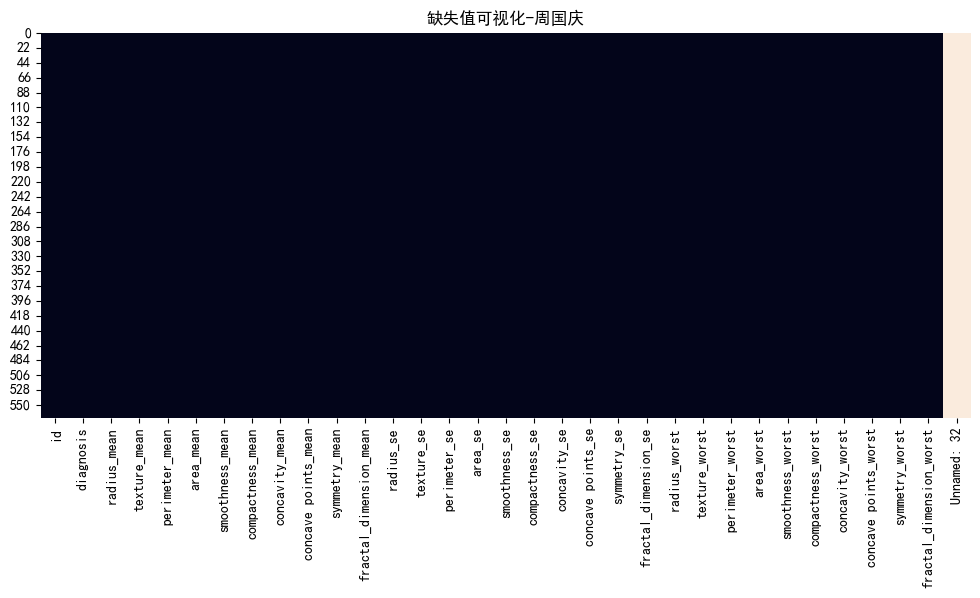

```python
plt.figure(figsize=(12,5))
sns.heatmap(
    df.isnull(),
    cbar=False
)
plt.title("缺失值可视化-周国庆")
plt.show()
```

## 缺失值分析

```python
print(f"清洗前形状: {df.shape}")
```

```
清洗前形状: (569, 33)
```

```python
df.drop(columns=['id', 'Unnamed: 32'], inplace=True, errors='ignore')
print(f"清洗后形状: {df.shape}")
```

```
清洗后形状: (569, 31)
```

```python
df.head().T
```

|  | 0 | 1 | 2 | 3 | 4 |
| --- | --- | --- | --- | --- | --- |
| diagnosis | M | M | M | M | M |
| radius_mean | 17.99 | 20.57 | 19.69 | 11.42 | 20.29 |
| texture_mean | 10.38 | 17.77 | 21.25 | 20.38 | 14.34 |
| perimeter_mean | 122.8 | 132.9 | 130.0 | 77.58 | 135.1 |
| area_mean | 1001.0 | 1326.0 | 1203.0 | 386.1 | 1297.0 |
| smoothness_mean | 0.1184 | 0.08474 | 0.1096 | 0.1425 | 0.1003 |
| compactness_mean | 0.2776 | 0.07864 | 0.1599 | 0.2839 | 0.1328 |
| concavity_mean | 0.3001 | 0.0869 | 0.1974 | 0.2414 | 0.198 |
| concave points_mean | 0.1471 | 0.07017 | 0.1279 | 0.1052 | 0.1043 |
| symmetry_mean | 0.2419 | 0.1812 | 0.2069 | 0.2597 | 0.1809 |
| fractal_dimension_mean | 0.07871 | 0.05667 | 0.05999 | 0.09744 | 0.05883 |
| radius_se | 1.095 | 0.5435 | 0.7456 | 0.4956 | 0.7572 |
| texture_se | 0.9053 | 0.7339 | 0.7869 | 1.156 | 0.7813 |
| perimeter_se | 8.589 | 3.398 | 4.585 | 3.445 | 5.438 |
| area_se | 153.4 | 74.08 | 94.03 | 27.23 | 94.44 |
| smoothness_se | 0.006399 | 0.005225 | 0.00615 | 0.00911 | 0.01149 |
| compactness_se | 0.04904 | 0.01308 | 0.04006 | 0.07458 | 0.02461 |
| concavity_se | 0.05373 | 0.0186 | 0.03832 | 0.05661 | 0.05688 |
| concave points_se | 0.01587 | 0.0134 | 0.02058 | 0.01867 | 0.01885 |
| symmetry_se | 0.03003 | 0.01389 | 0.0225 | 0.05963 | 0.01756 |
| fractal_dimension_se | 0.006193 | 0.003532 | 0.004571 | 0.009208 | 0.005115 |
| radius_worst | 25.38 | 24.99 | 23.57 | 14.91 | 22.54 |
| texture_worst | 17.33 | 23.41 | 25.53 | 26.5 | 16.67 |
| perimeter_worst | 184.6 | 158.8 | 152.5 | 98.87 | 152.2 |
| area_worst | 2019.0 | 1956.0 | 1709.0 | 567.7 | 1575.0 |
| smoothness_worst | 0.1622 | 0.1238 | 0.1444 | 0.2098 | 0.1374 |
| compactness_worst | 0.6656 | 0.1866 | 0.4245 | 0.8663 | 0.205 |
| concavity_worst | 0.7119 | 0.2416 | 0.4504 | 0.6869 | 0.4 |
| concave points_worst | 0.2654 | 0.186 | 0.243 | 0.2575 | 0.1625 |
| symmetry_worst | 0.4601 | 0.275 | 0.3613 | 0.6638 | 0.2364 |
| fractal_dimension_worst | 0.1189 | 0.08902 | 0.08758 | 0.173 | 0.07678 |

```python
df['diagnosis'] = df['diagnosis'].map({'M':1, 'B':0})
```

```python
df['diagnosis'].value_counts()
```

```
diagnosis
0    357
1    212
Name: count, dtype: int64
```

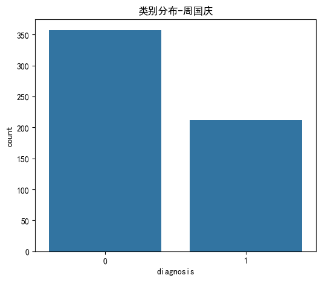

```python
plt.figure(figsize=(6,5))
sns.countplot(x='diagnosis', data=df)
plt.title("类别分布-周国庆")
plt.show()
```

## 类别分布分析

良性肿瘤与恶性肿瘤样本数量并不完全均衡。 从统计结果可以发现： 良性样本数量略多于恶性样本。 虽然不属于严重类别失衡问题，但后续评价模型时仍需要结合Precision、Recall以及F1-score进行综合分析，而不能仅依赖Accuracy。

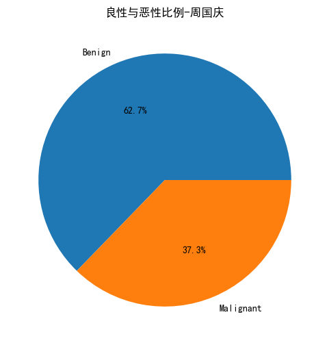

```python
class_names = ['Benign', 'Malignant']
counts = df['diagnosis'].value_counts()

plt.figure(figsize=(6,6))
plt.pie(counts, labels=class_names, autopct='%1.1f%%')
plt.title("良性与恶性比例-周国庆")
plt.show()
```

## 医学意义分析

从类别比例可以发现，恶性肿瘤样本占比较低。 在真实医疗场景中，漏诊恶性肿瘤的代价远高于误诊良性肿瘤。因此后续实验中Recall指标具有特别重要的意义，高Recall意味着模型能够尽可能发现潜在恶性病例。

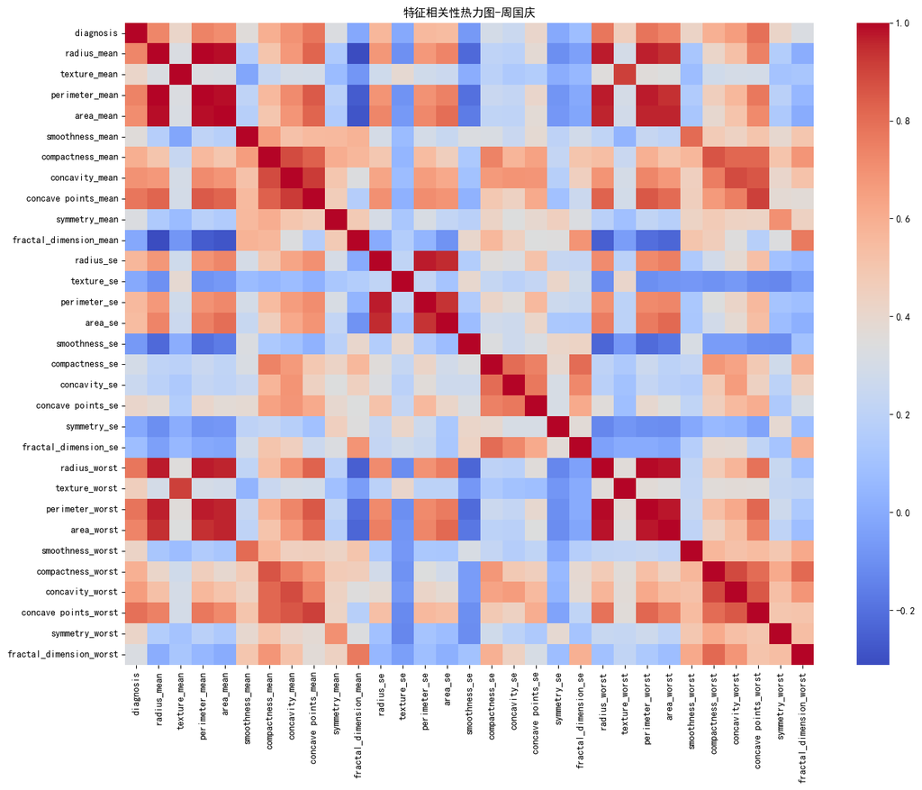

```python
corr = df.corr(numeric_only=True)

plt.figure(figsize=(16,12))
sns.heatmap(corr, cmap='coolwarm')
plt.title("特征相关性热力图-周国庆")
plt.show()
```

## 特征相关性分析

乳腺癌数据集中包含大量形态学特征。 通过相关性热力图可以发现： 部分特征之间具有较强相关关系，例如：

- radius
- perimeter
- area

这些指标均反映细胞核大小，因此存在明显共线性。 这一现象提示我们后续可以采用降维方法减少特征冗余。

```python
corr_target = corr['diagnosis'].sort_values(ascending=False)
corr_target.head(15)
```

```
diagnosis               1.000000
concave points_worst    0.793566
perimeter_worst         0.782914
concave points_mean     0.776614
radius_worst            0.776454
perimeter_mean          0.742636
area_worst              0.733825
radius_mean             0.730029
area_mean               0.708984
concavity_mean          0.696360
concavity_worst         0.659610
compactness_mean        0.596534
compactness_worst       0.590998
radius_se               0.567134
perimeter_se            0.556141
Name: diagnosis, dtype: float64
```

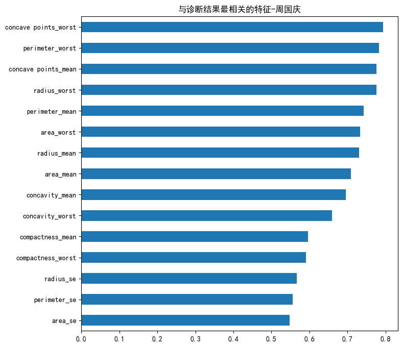

```python
plt.figure(figsize=(8,8))
corr_target[1:16].sort_values().plot.barh()
plt.title("与诊断结果最相关的特征-周国庆")
plt.show()
```

## 最重要特征分析

从相关性排序结果可以发现： 若干特征与恶性肿瘤具有显著相关关系。 例如：

- concave points worst
- perimeter worst
- radius worst
- area worst

这些指标均与细胞核大小和边缘不规则程度有关。 从医学角度来看，恶性肿瘤细胞通常表现出更强异形性和侵袭性，因此这些特征具有较高诊断价值。

```python
top_features = corr_target.index[1:11]
top_features
```

```
Index(['concave points_worst', 'perimeter_worst', 'concave points_mean',
       'radius_worst', 'perimeter_mean', 'area_worst', 'radius_mean',
       'area_mean', 'concavity_mean', 'concavity_worst'],
      dtype='str')
```

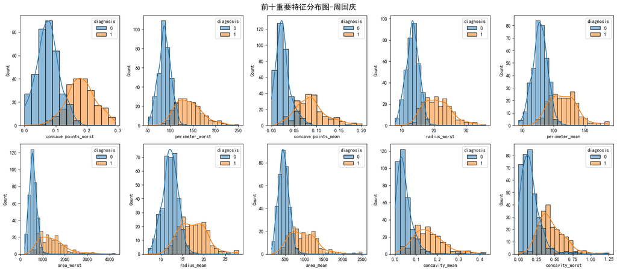

```python
fig, axes = plt.subplots(2, 5, figsize=(18,8))

for ax, feature in zip(axes.flat, top_features):
    sns.histplot(
        data=df, x=feature, hue='diagnosis',
        kde=True, ax=ax
    )

fig.suptitle("前十重要特征分布图-周国庆", fontsize=16)
plt.tight_layout()
plt.show()
```

## 特征分布分析

通过观察特征分布图可以发现： 恶性肿瘤与良性肿瘤在多个关键指标上存在明显差异。 例如在radius worst和perimeter worst等特征上，两类样本呈现较明显分离趋势。 这说明这些特征具备较强判别能力，也解释了为什么机器学习模型能够取得较高分类准确率。

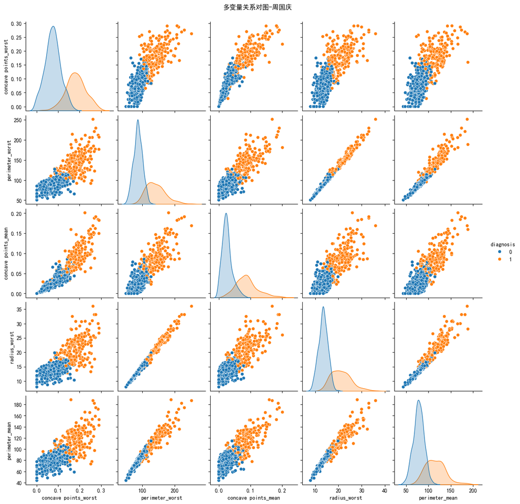

```python
top5 = list(top_features[:5])

sns.pairplot(df[top5 + ['diagnosis']], hue='diagnosis')
plt.suptitle("多变量关系对图-周国庆", y=1.02)
plt.show()
```

## 多变量关系分析

PairPlot进一步展示了多个重要特征之间的联合分布情况。 可以发现： 恶性与良性样本在二维特征空间中已经形成一定程度分离。 这意味着即使采用简单分类器，也能够建立较好的决策边界。 同时也说明该数据集具有较高可分性。

## 三、高维数据可视化与降维分析

乳腺癌数据集包含30个连续特征，因此属于典型高维数据。 高维数据虽然能够保留更多信息，但也会带来：

- 可视化困难
- 特征冗余
- 模型复杂度增加

因此本节采用PCA与t-SNE两种经典降维方法研究数据内部结构。 PCA属于线性降维方法，能够最大化保留原始数据方差信息；t-SNE属于非线性降维方法，更适合观察高维数据在局部空间中的聚类结构。

### 数据标准化

由于各特征量纲差异较大（例如area的范围远大于radius），在降维和建模之前需要进行标准化处理。 标准化可以消除量纲影响，使每个特征具有相同权重。

```python
X = df.drop(columns=['diagnosis'])
y = df['diagnosis']

scaler = StandardScaler()
X_scaled = scaler.fit_transform(X)

print(X_scaled.shape)
```

```
(569, 30)
```

### PCA降维分析

主成分分析（Principal Component Analysis，PCA）是一种经典线性降维方法。 其核心思想是寻找新的坐标轴方向，使得投影后的数据能够保留尽可能多的原始信息。 首先分析各主成分的解释方差比例。

```python
from sklearn.decomposition import PCA

pca_full = PCA()
pca_full.fit(X_scaled)

explained_ratio = pca_full.explained_variance_ratio_
```

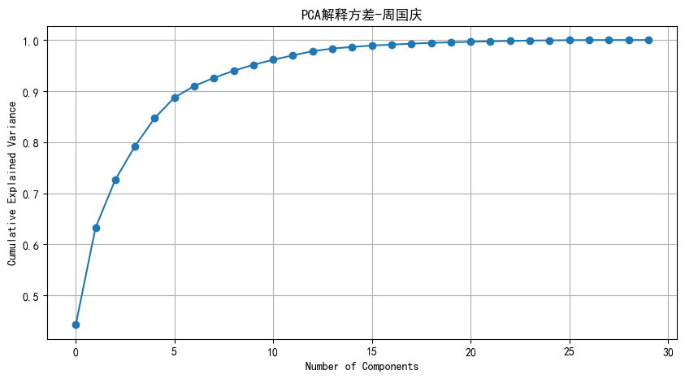

```python
plt.figure(figsize=(10,5))
plt.plot(np.cumsum(explained_ratio), marker='o')
plt.xlabel("Number of Components")
plt.ylabel("Cumulative Explained Variance")
plt.title("PCA解释方差-周国庆")
plt.grid()
plt.show()
```

### PCA解释方差分析

累计解释方差曲线能够反映降维后保留的信息量。 如果少量主成分即可解释大部分方差，则说明原始特征存在较强冗余。 从实验结果可以发现，仅使用少数几个主成分便能够保留绝大部分信息，这进一步验证了前面相关性分析中发现的特征共线性现象。 因此后续模型实际上并不一定需要全部30个特征才能获得较好性能。

```python
pca = PCA(n_components=2)
X_pca = pca.fit_transform(X_scaled)
X_pca.shape
```

```
(569, 2)
```

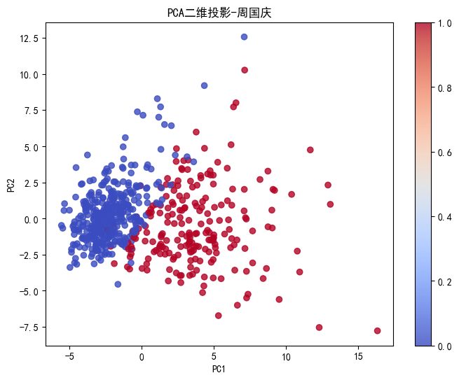

```python
plt.figure(figsize=(8,6))
scatter = plt.scatter(
    X_pca[:,0], X_pca[:,1],
    c=y, cmap='coolwarm', alpha=0.8
)
plt.xlabel("PC1")
plt.ylabel("PC2")
plt.title("PCA二维投影-周国庆")
plt.colorbar(scatter)
plt.show()
```

### PCA二维投影分析

从二维PCA投影结果可以发现，良性与恶性样本已经表现出较明显分离趋势。 虽然仍存在少量重叠区域，但总体上两类样本形成了不同聚类结构。 这一现象说明乳腺癌数据本身具有较高可分性，也解释了后续分类模型通常能够取得较高准确率。

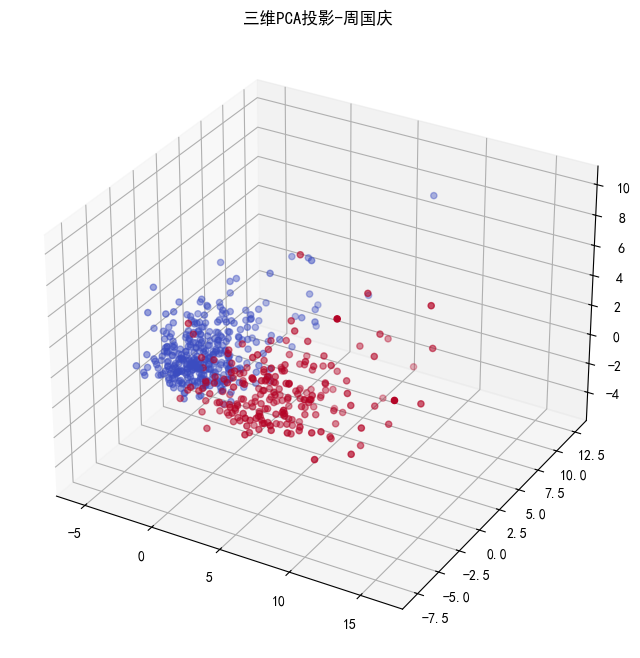

```python
from mpl_toolkits.mplot3d import Axes3D

pca3 = PCA(n_components=3)
X_pca3 = pca3.fit_transform(X_scaled)

fig = plt.figure(figsize=(10,8))
ax = fig.add_subplot(111, projection='3d')
scatter = ax.scatter(
    X_pca3[:,0], X_pca3[:,1], X_pca3[:,2],
    c=y, cmap='coolwarm'
)
ax.set_title("三维PCA投影-周国庆")
plt.show()
```

### t-SNE降维分析

虽然PCA能够保留全局结构，但对于复杂非线性关系刻画能力有限。 因此进一步采用t-SNE方法进行非线性降维分析。 t-SNE特别适用于观察高维数据在局部邻域中的聚类结构。

```python
from sklearn.manifold import TSNE

tsne = TSNE(n_components=2, random_state=42, perplexity=30)
X_tsne = tsne.fit_transform(X_scaled)
```

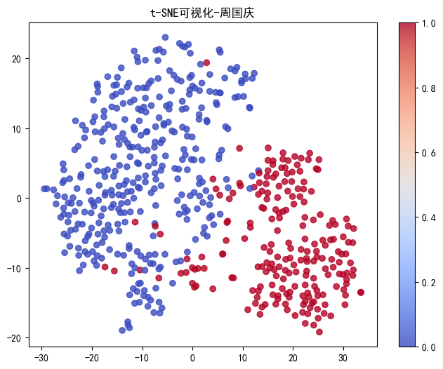

```python
plt.figure(figsize=(8,6))
scatter = plt.scatter(
    X_tsne[:,0], X_tsne[:,1],
    c=y, cmap='coolwarm', alpha=0.8
)
plt.colorbar(scatter)
plt.title("t-SNE可视化-周国庆")
plt.show()
```

### t-SNE结果分析

相比PCA，t-SNE更加关注局部邻域关系。 从可视化结果可以发现，良性与恶性样本形成了两个较为独立的聚类区域，类别边界更加明显。 这一结果说明乳腺癌数据在高维空间中本身具有较强聚类特征，因此深度学习模型能够较容易学习到有效分类边界。

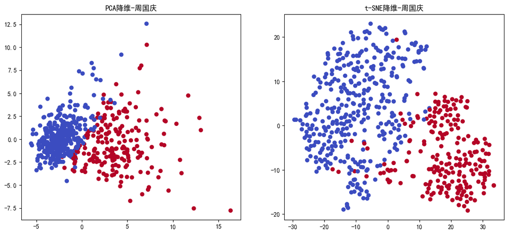

```python
fig, ax = plt.subplots(1, 2, figsize=(14,6))

ax[0].scatter(X_pca[:,0], X_pca[:,1], c=y, cmap='coolwarm')
ax[0].set_title("PCA降维-周国庆")

ax[1].scatter(X_tsne[:,0], X_tsne[:,1], c=y, cmap='coolwarm')
ax[1].set_title("t-SNE降维-周国庆")

plt.show()
```

### PCA与t-SNE比较

PCA主要保留全局结构，因此能够反映数据总体分布趋势。 t-SNE更加关注局部邻域结构，因此在类别聚类效果上通常更加明显。 从实验结果来看，两种降维方法均能够观察到良恶性样本之间的明显差异，这进一步说明当前数据集具有较好的可分类性。

## 数据集划分

完成探索性分析后，需要构建训练集与测试集。 为了保证类别比例一致，采用分层抽样（Stratified Sampling）方式进行划分。 训练集用于模型训练，测试集用于最终性能评价。

```python
X_train, X_test, y_train, y_test = train_test_split(
    X_scaled, y,
    test_size=0.2, random_state=42, stratify=y
)

print(X_train.shape, X_test.shape)
```

```
(455, 30) (114, 30)
```

```python
y_train.value_counts(), y_test.value_counts()
```

```
(diagnosis
 0    285
 1    170
 Name: count, dtype: int64,
 diagnosis
 0    72
 1    42
 Name: count, dtype: int64)
```

### 数据划分结果分析

采用80%训练集与20%测试集划分策略后，训练集和测试集中的类别比例基本保持一致。 这种分层抽样方式能够避免类别分布偏移带来的评价误差，从而保证实验结果更加可靠。

## 四、深度学习模型构建与实验

经过前面的探索性分析可以发现，乳腺癌数据集具有较好的类别可分性，但同时也存在部分特征冗余和类别边界重叠现象。 为了研究不同深度学习模型在医学诊断任务中的表现，本实验设计六种具有代表性的模型：

1. Baseline MLP — 基线神经网络 2. RBF Neural Network — 径向基神经网络 3. Genetic Algorithm Optimized MLP — 遗传算法优化MLP 4. Residual Neural Network — 残差神经网络 5. Transformer Encoder — 基于自注意力机制的分类模型 6. AutoEncoder + Classifier — 自编码器特征学习模型 实验将从模型结构、训练过程、分类性能以及泛化能力等多个角度进行比较分析。

### 4.1 实验评价指标

为了全面评价模型性能，本实验采用以下指标：

- Accuracy（准确率）
- Precision（精确率）
- Recall（召回率）
- F1-score
- ROC-AUC
- Training Time（训练时间）

其中Recall对于医学诊断尤其重要，因为其反映模型发现恶性肿瘤患者的能力。 漏诊恶性肿瘤的代价远高于误诊良性肿瘤，因此后续分析将重点关注Recall和ROC-AUC指标。

```python
import torch
import torch.nn as nn
import torch.optim as optim

from sklearn.metrics import (
    accuracy_score, precision_score, recall_score, f1_score,
    roc_auc_score, confusion_matrix, classification_report,
    roc_curve
)

import time
```

```python
device = torch.device("cuda" if torch.cuda.is_available() else "cpu")
print("Device:", device)
```

```
Device: cuda
```

```python
X_train_tensor = torch.tensor(X_train, dtype=torch.float32)
X_test_tensor = torch.tensor(X_test, dtype=torch.float32)
y_train_tensor = torch.tensor(y_train.values, dtype=torch.float32).view(-1,1)
y_test_tensor = torch.tensor(y_test.values, dtype=torch.float32).view(-1,1)
```

```python
results = []
```

```python
def evaluate_model(model, X_test, y_test, model_name, train_time):
    model.eval()
    with torch.no_grad():
        prob = torch.sigmoid(model(X_test.to(device)))
        pred = (prob > 0.5).cpu().numpy().astype(int)
    y_true = y_test.cpu().numpy()

    acc = accuracy_score(y_true, pred)
    precision = precision_score(y_true, pred)
    recall = recall_score(y_true, pred)
    f1 = f1_score(y_true, pred)
    auc = roc_auc_score(y_true, prob.cpu().numpy())

    results.append([model_name, acc, precision, recall, f1, auc, train_time])

    print(classification_report(y_true, pred))
    return pred, prob
```

### 4.2 Baseline MLP

多层感知机（Multi-Layer Perceptron，MLP）是最经典的前馈神经网络结构，也是后续所有模型的重要基础。 本实验首先构建一个简单的两层隐藏层神经网络作为Baseline模型，用于建立性能基准。 网络结构如下：

```
graph LR
    Input["Input(30)"] --> Dense64["Dense(64)"]
    Dense64 --> ReLU1["ReLU"]
    ReLU1 --> Dense32["Dense(32)"]
    Dense32 --> ReLU2["ReLU"]
    ReLU2 --> Output["Output(1)"]
```

该模型不包含任何特殊机制，因此能够反映最基础神经网络在乳腺癌分类任务中的表现。

```python
class BaselineMLP(nn.Module):
    def __init__(self):
        super().__init__()
        self.net = nn.Sequential(
            nn.Linear(30, 64),
            nn.ReLU(),
            nn.Linear(64, 32),
            nn.ReLU(),
            nn.Linear(32, 1)
        )
    def forward(self, x):
        return self.net(x)
```

```python
baseline = BaselineMLP().to(device)
criterion = nn.BCEWithLogitsLoss()
optimizer = optim.Adam(baseline.parameters(), lr=0.001)
```

#### Baseline训练过程

为了观察模型收敛情况，记录每个Epoch的Loss变化。 如果Loss能够稳定下降，则说明模型成功学习到乳腺癌特征与分类标签之间的映射关系。

```python
epochs = 100
loss_history = []
start = time.time()

for epoch in range(epochs):
    baseline.train()
    optimizer.zero_grad()
    outputs = baseline(X_train_tensor.to(device))
    loss = criterion(outputs, y_train_tensor.to(device))
    loss.backward()
    optimizer.step()
    loss_history.append(loss.item())

train_time_base = time.time() - start
print(f"训练完成，耗时: {train_time_base:.4f}s")
```

```
训练完成，耗时: 0.3488s
```

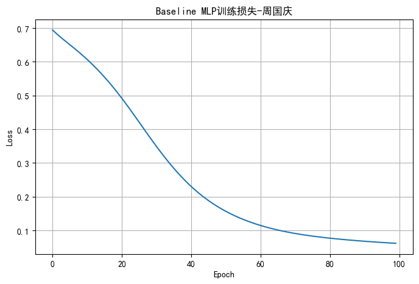

```python
plt.figure(figsize=(8,5))
plt.plot(loss_history)
plt.title("Baseline MLP训练损失-周国庆")
plt.xlabel("Epoch")
plt.ylabel("Loss")
plt.grid()
plt.show()
```

#### Baseline训练分析

```python
pred_base, prob_base = evaluate_model(
    baseline, X_test_tensor, y_test_tensor,
    "Baseline MLP", train_time_base
)
```

```
              precision    recall  f1-score   support

         0.0       0.99      1.00      0.99        72
         1.0       1.00      0.98      0.99        42

    accuracy                           0.99       114
   macro avg       0.99      0.99      0.99       114
weighted avg       0.99      0.99      0.99       114
```

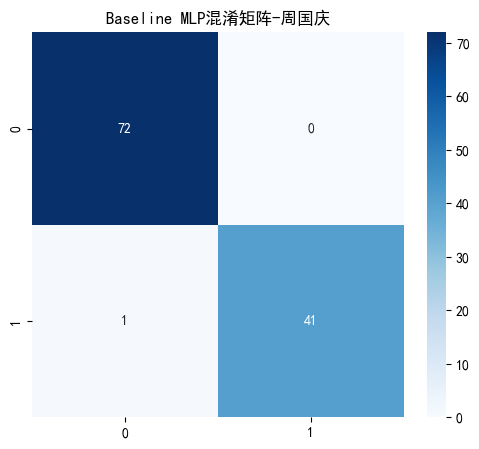

```python
cm = confusion_matrix(y_test, pred_base)
plt.figure(figsize=(6,5))
sns.heatmap(cm, annot=True, fmt='d', cmap='Blues')
plt.title("Baseline MLP混淆矩阵-周国庆")
plt.show()
```

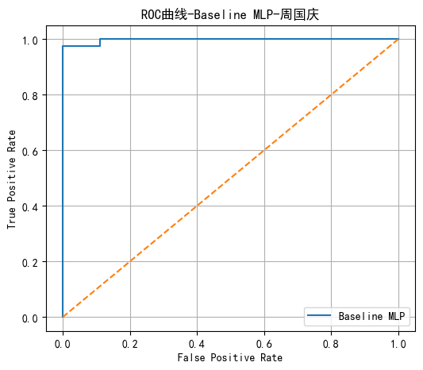

```python
fpr, tpr, _ = roc_curve(y_test, prob_base.cpu().numpy())
plt.figure(figsize=(6,5))
plt.plot(fpr, tpr, label='Baseline MLP')
plt.plot([0,1], [0,1], '--')
plt.xlabel("False Positive Rate")
plt.ylabel("True Positive Rate")
plt.title("ROC曲线-Baseline MLP-周国庆")
plt.legend()
plt.grid()
plt.show()
```

#### Baseline模型结果分析

从混淆矩阵和ROC曲线可以发现，简单MLP已经能够实现较高分类性能。这说明乳腺癌数据集中的特征具有较强判别能力。 然而，当前模型结构仍然较浅，其特征表达能力有限，因此后续将进一步探索更复杂网络结构能否带来性能提升。

### 4.3 RBF Neural Network

径向基神经网络（Radial Basis Function Network，RBF）是一类具有局部响应特性的前馈神经网络。 与MLP通过层层非线性映射学习复杂函数不同，RBF网络采用高斯核函数作为隐藏层激活函数，其输出仅对输入空间局部区域产生响应，因此特别适合样本规模较小且类别边界较清晰的问题。 RBF隐藏层计算形式如下： $$ \phi(x)=e^{-\frac{||x-c||^2}{2\sigma^2}} $$ 其中：

- $c$表示中心点
- $\sigma$表示核宽度

本实验首先利用K-Means寻找聚类中心，然后构建RBF隐藏层完成分类任务。

```python
from sklearn.cluster import KMeans
```

```python
n_centers = 50
kmeans = KMeans(n_clusters=n_centers, random_state=42)
kmeans.fit(X_train)

centers = torch.tensor(kmeans.cluster_centers_, dtype=torch.float32).to(device)
print(centers.shape)
```

```
torch.Size([50, 30])
```

```python
class RBFNetwork(nn.Module):
    def __init__(self, centers_num):
        super().__init__()
        self.centers = nn.Parameter(centers, requires_grad=False)
        self.beta = nn.Parameter(torch.ones(centers_num))
        self.fc = nn.Linear(centers_num, 1)

    def rbf(self, x):
        diff = x.unsqueeze(1) - self.centers
        dist = torch.sum(diff**2, dim=2)
        return torch.exp(-self.beta * dist)

    def forward(self, x):
        x = self.rbf(x)
        return self.fc(x)
```

```python
rbf_model = RBFNetwork(n_centers).to(device)
criterion = nn.BCEWithLogitsLoss()
optimizer = optim.Adam(rbf_model.parameters(), lr=0.001)
```

```python
rbf_loss = []
start = time.time()

for epoch in range(1000):
    optimizer.zero_grad()
    output = rbf_model(X_train_tensor.to(device))
    loss = criterion(output, y_train_tensor.to(device))
    loss.backward()
    optimizer.step()
    rbf_loss.append(loss.item())

rbf_time = time.time() - start
print(f"RBF训练完成，耗时: {rbf_time:.4f}s")
```

```
RBF训练完成，耗时: 1.3063s
```

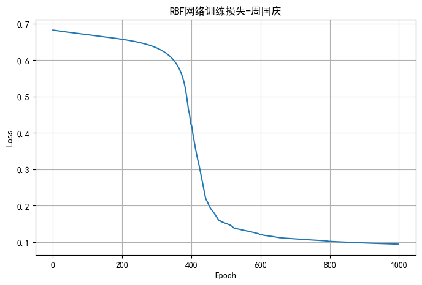

```python
plt.figure(figsize=(8,5))
plt.plot(rbf_loss)
plt.title("RBF网络训练损失-周国庆")
plt.xlabel("Epoch")
plt.ylabel("Loss")
plt.grid()
plt.show()
```

```python
pred_rbf, prob_rbf = evaluate_model(
    rbf_model, X_test_tensor, y_test_tensor,
    "RBF Network", rbf_time
)
```

```
              precision    recall  f1-score   support

         0.0       0.96      1.00      0.98        72
         1.0       1.00      0.93      0.96        42

    accuracy                           0.97       114
   macro avg       0.98      0.96      0.97       114
weighted avg       0.97      0.97      0.97       114
```

#### RBF模型分析

从训练损失曲线可以观察到，与传统MLP的平滑收敛过程不同，RBF网络并未在训练初期快速收敛，而是经历了较长时间的缓慢优化阶段。在约400个Epoch附近，损失函数出现明显下降，随后逐渐趋于稳定。 分析其原因，RBF网络首先需要利用高斯核构建局部特征表示，而输出层则进一步学习这些局部特征与类别标签之间的映射关系。当分类器逐渐形成有效决策边界后，预测概率迅速向正确类别集中，从而导致交叉熵损失出现明显下降。 该现象说明RBF网络的优化过程具有较强的阶段性，与MLP连续渐进式学习特征的机制存在明显区别。这一结果表明，RBF网络更依赖于隐空间结构的逐步形成，而不像传统MLP那样在训练初期即可快速建立全局映射关系。

### 4.4 Genetic Algorithm Optimized MLP

神经网络性能高度依赖超参数选择。 传统方法通常采用人工调参或者网格搜索，但随着搜索空间扩大，效率会迅速下降。 遗传算法（Genetic Algorithm，GA）是一种模拟自然进化过程的全局优化算法。 其基本流程包括： 1. 初始化种群 2. 适应度评估 3. 选择 4. 交叉 5. 变异 6. 产生新种群 本实验利用遗传算法自动搜索MLP网络的关键超参数，包括：

- Hidden Size
- Learning Rate

以获得更优模型结构。

```python
import random
```

```python
hidden_candidates = [16, 32, 64, 128]
lr_candidates = [0.01, 0.005, 0.001, 0.0005]
```

```python
class GAMLP(nn.Module):
    def __init__(self, hidden):
        super().__init__()
        self.net = nn.Sequential(
            nn.Linear(30, hidden),
            nn.ReLU(),
            nn.Linear(hidden, 1)
        )
    def forward(self, x):
        return self.net(x)
```

```python
def fitness(hidden, lr):
    model = GAMLP(hidden).to(device)
    optimizer_ga = optim.Adam(model.parameters(), lr=lr)
    criterion_ga = nn.BCEWithLogitsLoss()

    for _ in range(20):
        optimizer_ga.zero_grad()
        output = model(X_train_tensor.to(device))
        loss = criterion_ga(output, y_train_tensor.to(device))
        loss.backward()
        optimizer_ga.step()

    model.eval()
    with torch.no_grad():
        pred = torch.sigmoid(model(X_test_tensor.to(device)))
        pred = (pred > 0.5).cpu().numpy()

    return accuracy_score(y_test, pred)
```

```python
population = []
for _ in range(10):
    population.append([
        random.choice(hidden_candidates),
        random.choice(lr_candidates)
    ])

print("初始种群:", population)
```

```
初始种群: [[128, 0.0005], [128, 0.0005], [128, 0.005], [128, 0.005], [16, 0.001], [128, 0.0005], [64, 0.0005], [128, 0.001], [16, 0.005], [32, 0.01]]
```

```python
history_best = []
```

```python
for generation in range(10):
    scores = []
    for hidden, lr in population:
        score = fitness(hidden, lr)
        scores.append(score)

    best_idx = np.argmax(scores)
    history_best.append(scores[best_idx])
    best_individual = population[best_idx]

    population = []
    for _ in range(10):
        child_hidden = random.choice([best_individual[0], random.choice(hidden_candidates)])
        child_lr = random.choice([best_individual[1], random.choice(lr_candidates)])
        population.append([child_hidden, child_lr])

    print(f"Generation {generation+1}: Best Acc = {scores[best_idx]:.4f}, Params = {best_individual}")
```

```
Generation 1: Best Acc = 0.9912, Params = [128, 0.005]
Generation 2: Best Acc = 0.9825, Params = [128, 0.01]
Generation 3: Best Acc = 0.9912, Params = [128, 0.01]
Generation 4: Best Acc = 0.9912, Params = [64, 0.01]
Generation 5: Best Acc = 0.9912, Params = [64, 0.01]
Generation 6: Best Acc = 0.9912, Params = [64, 0.01]
Generation 7: Best Acc = 0.9912, Params = [64, 0.01]
Generation 8: Best Acc = 0.9912, Params = [32, 0.01]
Generation 9: Best Acc = 0.9825, Params = [64, 0.01]
Generation 10: Best Acc = 0.9912, Params = [32, 0.01]
```

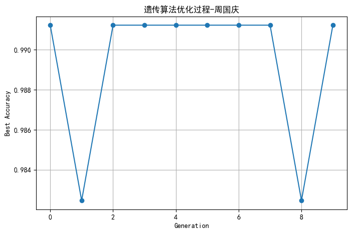

```python
plt.figure(figsize=(8,5))
plt.plot(history_best, marker='o')
plt.xlabel("Generation")
plt.ylabel("Best Accuracy")
plt.title("遗传算法优化过程-周国庆")
plt.grid()
plt.show()
```

```python
best_hidden = best_individual[0]
best_lr = best_individual[1]
print(f"最佳参数: hidden_size={best_hidden}, lr={best_lr}")
```

```
最佳参数: hidden_size=32, lr=0.01
```

```python
ga_model = GAMLP(best_hidden).to(device)
criterion = nn.BCEWithLogitsLoss()
optimizer = optim.Adam(ga_model.parameters(), lr=best_lr)
```

```python
ga_loss = []
start = time.time()

for epoch in range(100):
    optimizer.zero_grad()
    output = ga_model(X_train_tensor.to(device))
    loss = criterion(output, y_train_tensor.to(device))
    loss.backward()
    optimizer.step()
    ga_loss.append(loss.item())

ga_time = time.time() - start
print(f"GA-MLP训练完成，耗时: {ga_time:.4f}s")
```

```
GA-MLP训练完成，耗时: 0.1114s
```

```python
pred_ga, prob_ga = evaluate_model(
    ga_model, X_test_tensor, y_test_tensor,
    "GA Optimized MLP", ga_time
)
```

```
              precision    recall  f1-score   support

         0.0       0.95      1.00      0.97        72
         1.0       1.00      0.90      0.95        42

    accuracy                           0.96       114
   macro avg       0.97      0.95      0.96       114
weighted avg       0.97      0.96      0.96       114
```

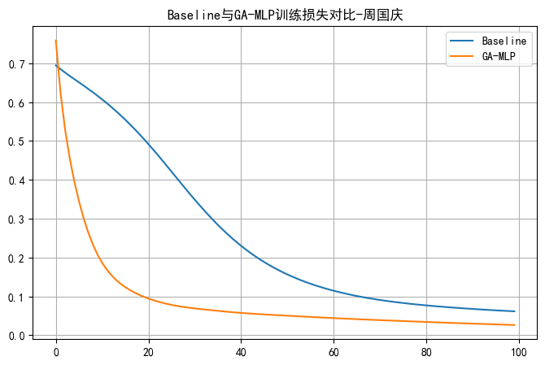

```python
plt.figure(figsize=(8,5))
plt.plot(loss_history, label='Baseline')
plt.plot(ga_loss, label='GA-MLP')
plt.legend()
plt.title("Baseline与GA-MLP训练损失对比-周国庆")
plt.grid()
plt.show()
```

### 4.5 Residual Neural Network

随着网络层数不断增加，神经网络可能出现梯度消失、训练困难以及性能退化等问题。 ResNet提出的残差连接（Residual Connection）通过直接将输入信息传递到后续层，有效缓解了深层网络训练中的退化问题。 其核心思想如下： $$ y = F(x) + x $$ 其中：

- $x$表示输入
- $F(x)$表示网络学习到的残差映射

相比直接学习复杂映射，学习残差通常更加容易，因此残差网络能够在更深层结构下保持稳定训练。 本实验构建基于全连接层的Residual Network，并研究其在乳腺癌分类任务中的表现。

```python
class ResidualBlock(nn.Module):
    def __init__(self, dim):
        super().__init__()
        self.block = nn.Sequential(
            nn.Linear(dim, dim),
            nn.ReLU(),
            nn.Linear(dim, dim)
        )
    def forward(self, x):
        return torch.relu(self.block(x) + x)
```

```python
class ResNetMLP(nn.Module):
    def __init__(self):
        super().__init__()
        self.input_layer = nn.Linear(30, 128)
        self.res1 = ResidualBlock(128)
        self.res2 = ResidualBlock(128)
        self.classifier = nn.Sequential(
            nn.Linear(128, 64),
            nn.ReLU(),
            nn.Linear(64, 1)
        )
    def forward(self, x):
        x = torch.relu(self.input_layer(x))
        x = self.res1(x)
        x = self.res2(x)
        return self.classifier(x)
```

```python
res_model = ResNetMLP().to(device)
criterion = nn.BCEWithLogitsLoss()
optimizer = optim.Adam(res_model.parameters(), lr=0.001)
```

```python
res_loss = []
start = time.time()

for epoch in range(100):
    optimizer.zero_grad()
    outputs = res_model(X_train_tensor.to(device))
    loss = criterion(outputs, y_train_tensor.to(device))
    loss.backward()
    optimizer.step()
    res_loss.append(loss.item())

res_time = time.time() - start
print(f"Residual训练完成，耗时: {res_time:.4f}s")
```

```
Residual训练完成，耗时: 0.2142s
```

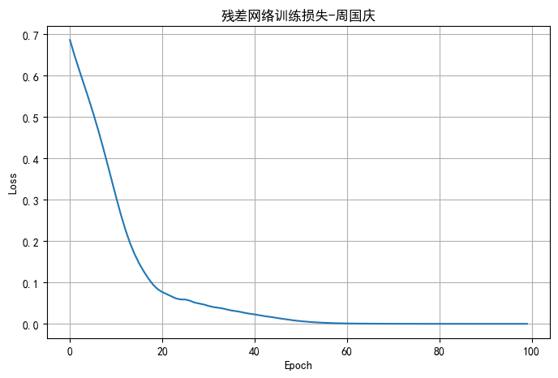

```python
plt.figure(figsize=(8,5))
plt.plot(res_loss)
plt.title("残差网络训练损失-周国庆")
plt.xlabel("Epoch")
plt.ylabel("Loss")
plt.grid()
plt.show()
```

```python
pred_res, prob_res = evaluate_model(
    res_model, X_test_tensor, y_test_tensor,
    "Residual Network", res_time
)
```

```
              precision    recall  f1-score   support

         0.0       0.97      0.97      0.97        72
         1.0       0.95      0.95      0.95        42

    accuracy                           0.96       114
   macro avg       0.96      0.96      0.96       114
weighted avg       0.96      0.96      0.96       114
```

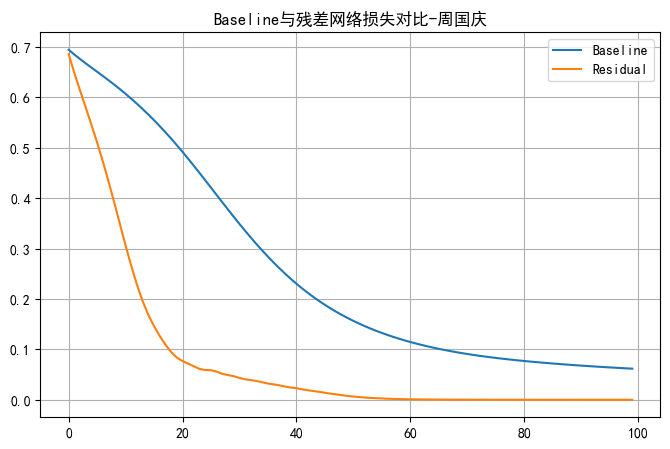

```python
plt.figure(figsize=(8,5))
plt.plot(loss_history, label="Baseline")
plt.plot(res_loss, label="Residual")
plt.legend()
plt.title("Baseline与残差网络损失对比-周国庆")
plt.grid()
plt.show()
```

#### Residual模型分析

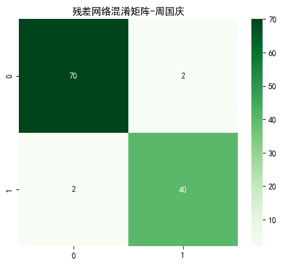

```python
cm = confusion_matrix(y_test, pred_res)
plt.figure(figsize=(6,5))
sns.heatmap(cm, annot=True, fmt='d', cmap='Greens')
plt.title("残差网络混淆矩阵-周国庆")
plt.show()
```

### 4.6 Transformer Encoder

近年来，Transformer已经成为深度学习领域最重要的模型之一。 其核心机制为Self-Attention（自注意力机制）。 传统神经网络主要依赖固定连接结构，而Transformer能够动态学习不同特征之间的重要关系。 对于乳腺癌数据集而言，各个细胞特征之间存在复杂关联，因此利用Attention机制建模特征依赖关系具有重要意义。 本实验构建简化版Transformer Encoder完成分类任务。

```python
class TransformerClassifier(nn.Module):
    def __init__(self):
        super().__init__()
        self.embedding = nn.Linear(1, 32)
        encoder_layer = nn.TransformerEncoderLayer(
            d_model=32, nhead=4, batch_first=True
        )
        self.transformer = nn.TransformerEncoder(encoder_layer, num_layers=2)
        self.fc = nn.Sequential(
            nn.Linear(32, 16),
            nn.ReLU(),
            nn.Linear(16, 1)
        )
    def forward(self, x):
        x = x.unsqueeze(-1)
        x = self.embedding(x)
        x = self.transformer(x)
        x = torch.mean(x, dim=1)
        return self.fc(x)
```

```python
transformer_model = TransformerClassifier().to(device)
criterion = nn.BCEWithLogitsLoss()
optimizer = optim.Adam(transformer_model.parameters(), lr=0.001)
```

```python
transformer_loss = []
start = time.time()

for epoch in range(100):
    optimizer.zero_grad()
    output = transformer_model(X_train_tensor.to(device))
    loss = criterion(output, y_train_tensor.to(device))
    loss.backward()
    optimizer.step()
    transformer_loss.append(loss.item())

transformer_time = time.time() - start
print(f"Transformer训练完成，耗时: {transformer_time:.4f}s")
```

```
Transformer训练完成，耗时: 3.6489s
```

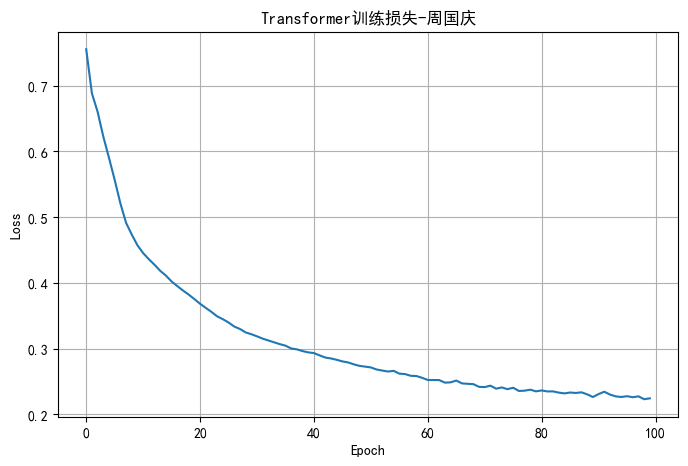

```python
plt.figure(figsize=(8,5))
plt.plot(transformer_loss)
plt.title("Transformer训练损失-周国庆")
plt.xlabel("Epoch")
plt.ylabel("Loss")
plt.grid()
plt.show()
```

```python
pred_trans, prob_trans = evaluate_model(
    transformer_model, X_test_tensor, y_test_tensor,
    "Transformer", transformer_time
)
```

```
              precision    recall  f1-score   support

         0.0       0.90      0.92      0.91        72
         1.0       0.85      0.83      0.84        42

    accuracy                           0.89       114
   macro avg       0.88      0.88      0.88       114
weighted avg       0.89      0.89      0.89       114
```

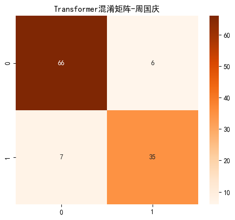

```python
cm = confusion_matrix(y_test, pred_trans)
plt.figure(figsize=(6,5))
sns.heatmap(cm, annot=True, fmt='d', cmap='Oranges')
plt.title("Transformer混淆矩阵-周国庆")
plt.show()
```

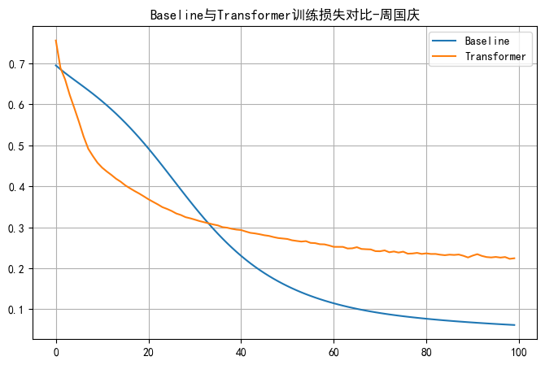

```python
plt.figure(figsize=(8,5))
plt.plot(loss_history, label="Baseline")
plt.plot(transformer_loss, label="Transformer")
plt.legend()
plt.title("Baseline与Transformer训练损失对比-周国庆")
plt.grid()
plt.show()
```

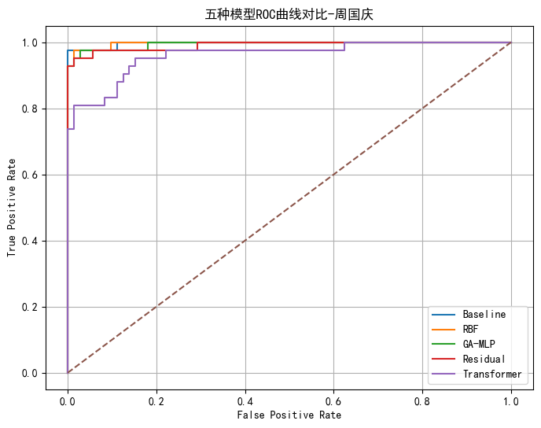

```python
plt.figure(figsize=(8,6))

for name, prob in [
    ("Baseline", prob_base),
    ("RBF", prob_rbf),
    ("GA-MLP", prob_ga),
    ("Residual", prob_res),
    ("Transformer", prob_trans)
]:
    fpr, tpr, _ = roc_curve(y_test, prob.cpu().numpy())
    plt.plot(fpr, tpr, label=name)

plt.plot([0,1], [0,1], '--')
plt.xlabel("False Positive Rate")
plt.ylabel("True Positive Rate")
plt.title("五种模型ROC曲线对比-周国庆")
plt.legend()
plt.grid()
plt.show()
```

### 4.7 AutoEncoder + Classifier

通过重构输入数据，AutoEncoder能够自动提取最具代表性的特征。 本实验首先训练AutoEncoder学习乳腺癌数据的潜在表示，然后利用Encoder输出的低维特征进行分类。

```python
class AutoEncoder(nn.Module):
    def __init__(self):
        super().__init__()
        self.encoder = nn.Sequential(
            nn.Linear(30, 64),
            nn.ReLU(),
            nn.Linear(64, 16)
        )
        self.decoder = nn.Sequential(
            nn.Linear(16, 64),
            nn.ReLU(),
            nn.Linear(64, 30)
        )
    def forward(self, x):
        latent = self.encoder(x)
        reconstructed = self.decoder(latent)
        return latent, reconstructed
```

```python
autoencoder = AutoEncoder().to(device)
criterion_ae = nn.MSELoss()
optimizer = optim.Adam(autoencoder.parameters(), lr=0.001)
```

#### AutoEncoder训练过程

由于AutoEncoder属于无监督学习，因此其训练目标并非预测标签，而是尽可能重构输入数据。 若重构误差持续下降，则说明模型成功学习到数据的潜在结构。

```python
ae_loss = []
start = time.time()

for epoch in range(200):
    optimizer.zero_grad()
    latent, reconstructed = autoencoder(X_train_tensor.to(device))
    loss = criterion_ae(reconstructed, X_train_tensor.to(device))
    loss.backward()
    optimizer.step()
    ae_loss.append(loss.item())

ae_time = time.time() - start
print(f"AutoEncoder训练完成，耗时: {ae_time:.4f}s")
```

```
AutoEncoder训练完成，耗时: 0.3123s
```

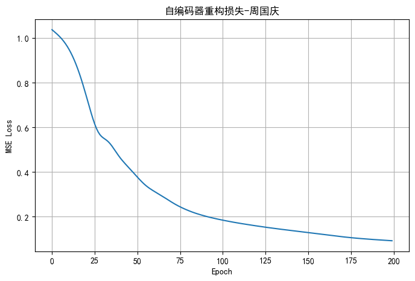

```python
plt.figure(figsize=(8,5))
plt.plot(ae_loss)
plt.title("自编码器重构损失-周国庆")
plt.xlabel("Epoch")
plt.ylabel("MSE Loss")
plt.grid()
plt.show()
```

#### AutoEncoder训练分析

从重构误差曲线可以观察到，模型在训练过程中不断降低输入与重构结果之间的差异。 说明Encoder成功提取出了乳腺癌数据的重要特征，同时Decoder能够利用这些低维特征恢复原始数据。 这一过程表明数据中的有效信息已经被压缩到潜空间表示中。

```python
autoencoder.eval()
with torch.no_grad():
    latent_train, _ = autoencoder(X_train_tensor.to(device))
    latent_test, _ = autoencoder(X_test_tensor.to(device))

latent_train = latent_train.cpu().numpy()
latent_test = latent_test.cpu().numpy()
print(latent_train.shape)
```

```
(455, 16)
```

#### 潜空间特征分析

经过Encoder压缩后，原始30维特征被映射到16维潜空间。 维度减少约一半，但模型仍保留了大部分重要信息。 接下来利用降维方法观察潜空间结构。

```python
from sklearn.decomposition import PCA

pca_latent = PCA(n_components=2)
latent_pca = pca_latent.fit_transform(latent_train)
```

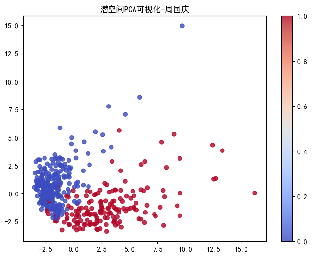

```python
plt.figure(figsize=(8,6))
scatter = plt.scatter(
    latent_pca[:,0], latent_pca[:,1],
    c=y_train, cmap='coolwarm', alpha=0.8
)
plt.colorbar(scatter)
plt.title("潜空间PCA可视化-周国庆")
plt.show()
```

#### 潜空间可视化分析

```python
from sklearn.manifold import TSNE

latent_tsne = TSNE(n_components=2, random_state=42).fit_transform(latent_train)
```

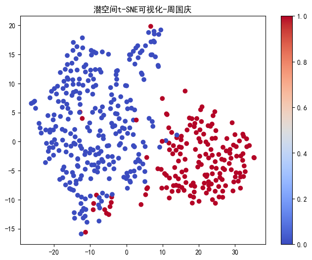

```python
plt.figure(figsize=(8,6))
scatter = plt.scatter(
    latent_tsne[:,0], latent_tsne[:,1],
    c=y_train, cmap='coolwarm'
)
plt.colorbar(scatter)
plt.title("潜空间t-SNE可视化-周国庆")
plt.show()
```

#### 潜空间聚类分析

t-SNE结果进一步证明Encoder学习到的低维表示具有较好的类别分离能力。 恶性与良性样本形成两个较明显聚类区域。 因此利用潜空间特征进行分类有望获得更优性能。

```python
class LatentClassifier(nn.Module):
    def __init__(self):
        super().__init__()
        self.net = nn.Sequential(
            nn.Linear(16, 32),
            nn.ReLU(),
            nn.Linear(32, 1)
        )
    def forward(self, x):
        return self.net(x)
```

```python
classifier = LatentClassifier().to(device)
criterion = nn.BCEWithLogitsLoss()
optimizer = optim.Adam(classifier.parameters(), lr=0.001)
```

```python
latent_train_tensor = torch.tensor(latent_train, dtype=torch.float32)
latent_test_tensor = torch.tensor(latent_test, dtype=torch.float32)
```

```python
classifier_loss = []
start = time.time()

for epoch in range(100):
    optimizer.zero_grad()
    outputs = classifier(latent_train_tensor.to(device))
    loss = criterion(outputs, y_train_tensor.to(device))
    loss.backward()
    optimizer.step()
    classifier_loss.append(loss.item())

ae_classifier_time = time.time() - start
print(f"AutoEncoder Classifier训练完成，耗时: {ae_classifier_time:.4f}s")
```

```
AutoEncoder Classifier训练完成，耗时: 0.1294s
```

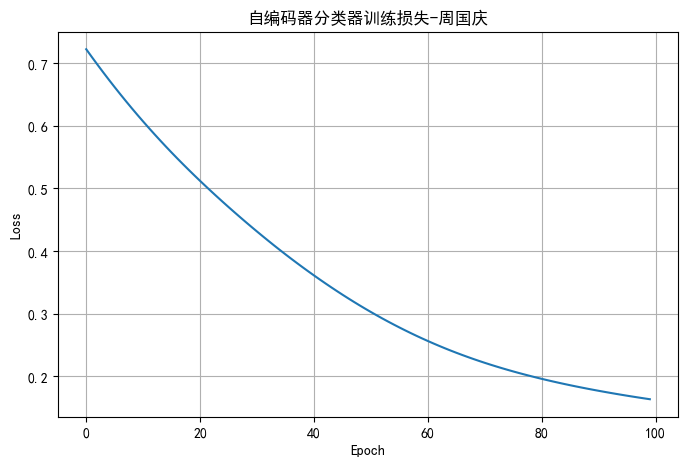

```python
plt.figure(figsize=(8,5))
plt.plot(classifier_loss)
plt.title("自编码器分类器训练损失-周国庆")
plt.xlabel("Epoch")
plt.ylabel("Loss")
plt.grid()
plt.show()
```

```python
pred_ae, prob_ae = evaluate_model(
    classifier, latent_test_tensor, y_test_tensor,
    "AutoEncoder+Classifier", ae_classifier_time
)
```

```
              precision    recall  f1-score   support

         0.0       0.95      0.97      0.96        72
         1.0       0.95      0.90      0.93        42

    accuracy                           0.95       114
   macro avg       0.95      0.94      0.94       114
weighted avg       0.95      0.95      0.95       114
```

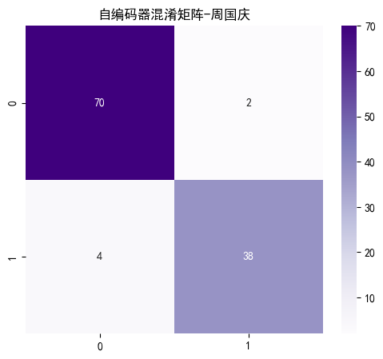

```python
cm = confusion_matrix(y_test, pred_ae)
plt.figure(figsize=(6,5))
sns.heatmap(cm, annot=True, fmt='d', cmap='Purples')
plt.title("自编码器混淆矩阵-周国庆")
plt.show()
```

#### AutoEncoder分类结果分析

通过先进行无监督特征学习，再进行监督分类，模型能够利用更加紧凑且具有判别性的特征表示。 从混淆矩阵可以发现，模型对于两类样本均具有较高识别能力。 说明Encoder提取的潜空间特征有效保留了乳腺癌诊断所需的重要信息。